```python
import numpy as np
from typing import Any, List, Union, Optional, Tuple, Callable
from fractions import Fraction
from math import *
import matplotlib.pyplot as plt
from itertools import product
```

# Arbres binaires

## Niveaux

Dans ce qui suit nous représenterons les `m` premiers niveaux d'un arbre binaire par une liste de `m` listes, chacune de $1,2,\cdots,2^{m-1}$ noeuds representant au niveau $0$ la racine, au niveau $1$ Les fils gauches et droits de la racine, et au niveau $k+1$ les fils gauches et droits du $i^{ème}$ noeud du niveau $k$ par respectivement les noeuds d'indices $2i$ et $2i+1$ de ce niveau $k+1$ où $i \in \{0,1,\ldots,k-1\}$.  
Ci-dessous une fonction `bin_levels(lst)` qui transforme une liste `lst` en les niveaux de l'arbre binaire correspondant.

```python
def bin_levels(lst: List[Any]) -> List[List[Any]]:
    """ divide a list in blocks (lists) corresponding to the first levels of a binary tree

    Args:
        lst:  a list
    Returns:
        a list of levels: [lvls[0],...,lvls[k],..., lvls[-1]]]
        length(lvls[0]) == 1, lvls[0][0] is the root of the binary tree
        for each level k > 0, len(lvls[k]) == 2*len(lvls[k-1]),
        but for the last level, len(lvls[-1]) <= 2*len(lvls[-2]) depending on len(lst)
    Example:
        if lst = [1, 2, 3, 4, 5, 6, 7, 8, 9, 10, 11, 12, 13, 14, 15]
        bin_levels(lst) -> [[1], [2, 3], [4, 5, 6, 7], [8, 9, 10, 11, 12, 13, 14, 15]]
    """
    n = len(lst)
    lvls = []
    m = 1
    while 2*m <= n:
        lvls.append(lst[m-1:2*m-1])
        m = 2*m
    lvls.append(lst[m-1:n+1])
    return lvls
```

```python
l13 = list(range(1,14))
print('l13 = {}'.format(l13))
print('levels:             0    1       2             3')
print('bin_levels(l13):  {}'.format(bin_levels(l13)))
```

```
l13 = [1, 2, 3, 4, 5, 6, 7, 8, 9, 10, 11, 12, 13]
levels:             0    1       2             3
bin_levels(l13):  [[1], [2, 3], [4, 5, 6, 7], [8, 9, 10, 11, 12, 13]]
```

Et `print_bintree(levels)` est un "pretty print" des arbres binaires représentés de cette façon.

```python
def print_bintree(lvls : List[List[Any]],r: int = 1, fmt: Callable[[Any],str] = str) -> None:
    """ pretty print of a binary tree defined by lvls as in the result
        of the bin_levels function

    Args:
        lvls: binary tree as a list of levels: [lvls[0],...,lvls[k],..., lvls[-1]]]
              length(lvls[0]) == 1, lvls[0][0] is the root of the binary tree
              for each level k > 0, len(lvls[k]) == 2*len(lvls[k-1]),
              but for the last level, len(lvls[-1]) <= 2*len(lvls[-2])
        r:    (int) w = 2*r+1 is the width of printed label for each node.
              default: r=1 => 3 characters for each node's label
        fmt:  a function defining the print format of each node.
              default: the function str
    Returns:
        None: this function is just for printing the first levels of a binary tree
    """
    def bn(klvl: int, r: int, n: int) -> int:
        """returns the half-distance between two nodes at level klvl

        Args:
            klvl: (int) the level number
            r:    (int) w = 2*r+1 is the width of label for each node
            n:    number of levels
        Returns:
            (int) the half-distance between two nodes at level klvl
        """
        return (2*r+1)*(2**(n-1-klvl)-1)
    n = len(lvls)
    # lbn: list of the half-distance lbn[k] between two nodes at each level k
    lbn = [bn(k,r,n) for k in range(n)]
    # lu[k]: length of horizontal branches in level k
    lu = [el//2 for el in lbn]
    # w: number of chars for each node
    w = 2*r+1
    for k in range(n):
        print(''.join([(lbn[k]+r)*' ' + '|' + (lbn[k]+3*r+1)*' ' for el in lvls[k]]))
        print(''.join([(lu[k]+(k!=(n-1)))*' ' + lu[k]*'_' + '{:^{}}'.format(fmt(el),w) +
                       lu[k]*'_'+ (lu[k]+(k!=(n-1))+2*r+1)*' ' for el in lvls[k]]))
```

```python
print_bintree(bin_levels(l13))
```

```
           __________ 1 __________
          |                       |
     ____ 2 ____             ____ 3 ____
    |           |           |           |
  _ 4 _       _ 5 _       _ 6 _       _ 7 _
 |     |     |     |     |     |
 8     9    10    11    12    13
```

## Chemin d'accès à un noeud (path string)

Nous utiliserons les lettres L (Left) et R (Right) quand nous nous déplaçons depuis la racine d'un arbre binaire, en suivant la branche gauche ou droite à chaque noeud, afin d'atteindre un noeud particulier de l'arbre; ainsi une chaîne composée de caractères L et R identifie de manière unique la place d'un noeud dans l'arbre.  
Par exemple dans l'arbre ci-dessus, pour atteindre le noeud portant l'entier 12 à partir de la racine 1 on va à droite vers 3 puis à gauche vers 6 et enfin à gauche vers 12. Ainsi le noeud portant l'étiquette 12 est identifié par le "chemin" `'RLL'`.  
La fonction `paths_level(k)` retourne la liste ordonnée des "chemins" identifiant tous les noeuds du $k^{ième}$ niveau d'un arbre binaire:

- `['']` pour la racine au niveau k = 0
- `['L', 'R']` pour les fils gauche et droit de la racine au premier niveau k = 1
- `['LL', 'LR', 'RL', 'RR']` au niveau k = 2, pour les fils gauche et droit respecti vement des noeuds du niveau 1  
  Et ainsi de suite ...

```python
def paths_level(k: int) -> List[str]:
    """ return the path strings describing the kth level of a binary tree:

    Args:
        k: an integer
    Returns:
        a list of strings, defining the ordered list of the level's nodes
    Examples:
        [''] for the root at level k = 0
        ['L', 'R'] for the left and right sons of the root at the first level k = 1,
        ['LL', 'LR', 'RL', 'RR'] at level k = 2 for the respective left and right sons of level 1 nodes
        """
    return [''.join(t) for t in product(('L','R'),repeat=k)]
```

```python
print(paths_level(3))
```

```
['LLL', 'LLR', 'LRL', 'LRR', 'RLL', 'RLR', 'RRL', 'RRR']
```

## Bits representation

```python
def ints2bin(ints: List[int], nbits: Optional[int] = None) -> List[str]:
    """ return the list of the binary representations on nbits of all integers in the list ints.

    Args:
        ints: a list of integers
        nbits: an integer, the fixed length for all the bits string representing the integers in ints.
        If nbits == None then for each integer in ints the binary representation is the string of minimal length
    Returns:
        The list of the binary representation of the integers in ints
    Example:
        ints2bin([1,2],nbits=3) ->  ['001', '010']
        ints2bin([1,2]) ->  ['1', '10']
    """
    return [np.binary_repr(k,nbits) for k in ints]

def rev_ints(ints: List[int], nbits: Optional[int] = None) -> List[int]:
    """return the list of integers resulting of the reversing of the binary repr of the integers in  ints

    Args:
        ints: a list of integers
        nbits: an integer, the fixed length for all the bits string representing the integers in ints.
        If nbits == None then for each integer in ints the binary representation is the string of minimal length
    Returns:
        the list of integers resulting of the reversing of the binary repr of the integers in  ints
    Example:
        rev_ints([1,2],nbits=3) -> [4, 2] (['001', '010'] -> ['100', '010'])
        rev_ints([1,2]) -> [1, 1] (['1', '10'] -> ['1', '1'])
    """
    return [int(bits[::-1],2) for bits in ints2bin(ints,nbits)]

def str_translate(s: str, fromchrs: str = '01', tochrs: str = '10') -> str:
    """substitute in the string s the characters in fromchrs to those in tochrs and return the resulting string

    Args:
        s: a string
        fromchrs: a string listing all the characters to be changed
        tochrs: a string listing the corresponding substitutes
    Returns:
        the string resulting from the substitutions in s.
    Examples:
       str_transl('1101') -> '0010'
       str_transl('LLRL','LR','01') -> '0010'
    """
    if s == '':
        return tochrs[0]
    return s.translate(dict(list(zip((map(ord,fromchrs)),tochrs))))
```

Par les substitutions: `L -> 0` and `R -> 1`, nous remplaçons l'indexation d'un noeud avec un "chemin" par une paire d'entiers `(level, idx)` indiquant la position `idx` du noeud dans la liste décrivant le niveau `level`.  
Par exemple le noeud de "chemin" `'RRL'` est le noeud d'indice `6` du niveau `3` (`len('RRL')`)  
parceque `str_translate('RRL','LR','01')` est `'110'` et `int('110',2)` is `6`. Se souvenir que le noeud d'indice `6` est le $7^{ième}$ noeud, l'indexation en Python commençant toujours par l'indice `0`.  
Nous définissons ci-dessous deux fonctions réciproques l'une de l'autre pour passer d'une indexation à l'autre: `level_idx(path_string)` et `path_str(level,idx)`

```python
def level_idx(path_string: str) -> Tuple[int, int]:
    """ returns a pair of integers(level_number,idx) identifying the positition
        idx of a node in the list representing the level in a binary tree.

    Args:
        path_string: a string of 'L' and 'R',describing the left and right from the root moves to reach a node
    Returns:
        a tuple of 2 integers: the node's level number and his index position in the corresponding list
    Example:
        level_idx('RRL') -> (3, 6)
        """
    return len(path_string), int(str_translate(path_string,'LR','01'), 2)
```

```python
level_idx('RRL')
```

```
(3, 6)
```

```python
def path_str(level: int, idx: int) -> str:
    """ returns the path string of the node defined by level and idx

    Args:
        level: (int) node's level number of the node the pair of integers(level,idx) identifies the positition idx of a node
        idx: (int) node's index in the list representing the level
    Returns:
        the node's corresponding path string
    Example:
        path_str(3,6) == 'RRL'
    """
    return str_translate(np.binary_repr(idx,level),'01','LR')
```

```python
path_str(3,6)
```

```
'RRL'
```

ces fonctions sont réciproques l'une de l'autre:

```python
level_idx(path_str(*(3,6))) == (3,6) and path_str(*level_idx('RRL')) == 'RRL'
```

```
True
```

Si nous effectuons la même substitution sur tous les "chemins" d'un niveau, comme par exemple ceux du niveau `3` donnés par `paths_level(3)` nous obtenons évidemment la liste des $2^3 = 8$ premiers entiers consécutifs:

```python
paths_lvl3 = paths_level(3)
print(paths_lvl3)
print([str_translate(s,'LR','01') for s in paths_lvl3])
print([level_idx(s)[1] for s in paths_lvl3])
```

```
['LLL', 'LLR', 'LRL', 'LRR', 'RLL', 'RLR', 'RRL', 'RRR']
['000', '001', '010', '011', '100', '101', '110', '111']
[0, 1, 2, 3, 4, 5, 6, 7]
```

# L'arbre binaire de Stern-Brocot

Les cellules de textes de ce chapitre sont pour la plupart une transcription du chapitre consacré à l'arbre de Stern-Brocot dans le livre de Donald Knuth *Concrete Mathematics* (p.129) et les cellules de code matérialisent en Python les concepts exposés dans ce chapitre.

Une belle construction de l'ensemble de toutes les fractions positives ou nulle $m/n$ avec $m \perp n$ est celle de la construction de l'arbre binaire de Stern-Brocot.  
Ici nous utilisons la notation $m \perp n$ de Donald Knuth pour désigner la relation entre deux entiers $m,n$: "$m$ et $n$ sont premiers entre eux (copremiers)". Ce qui revient aussi à dire que le plus grand commun dénominateur de $m$ et $n$ est 1 ($pgcd(m,n) = m \wedge n = 1$)  
Une fraction $m/n$ est dite irréductible si et seulement si $m \perp n$ .  
L'idée est la suivante: On commence avec la paire $(0/1, 1/0)$ la plus petite fraction positive ou nulle et la plus grande (en fait on a ajouté la paire d'entiers (numérateur=1,dénominateur=0) pour noter l'$\infty$ qui ne sera jamais atteint!)  
Ensuite on répète l'opération suivante aussi longtemps qu'on le désire:  
Insérer $(m + m')/(n + n')$ entre deux fractions adjacentes $m/n$ and $m'/n'$. La nouvelle fraction **(m+m')/(n+n')** est appelée la **médiante** de **m/n** and **m'/n'**.  
Le premier pas nous donne la médiante de $0/1$ et $1/0$, soit $1/1$.  
le second pas nous donne deux nouvelles fractions: la médiante $1/2$ entre $0/1$ et $1/1$ d'un côté et la médiante $2/1$ entre $1/1$ et $1/0$.  
Et ainsi de suite en construisant un arbre binaire de racine $1/1$.

## Arbre des numérateurs

Pour commencer nous allons d'abord construire l'arbre binaire correspondant aux numérateurs de toutes les fractions de l'arbre de Stern-Brocot. Nous partons donc de la paire d'entiers (0,1) et nous répétons autant de fois que nous le désirons, c'est à dire jusqu'au niveau désiré, l'opération suivante:  
Insérer m + m' entre deux entiers adjacents m et m'.  
Construire ainsi successivement chaque niveau et en même temps construire une liste "cumulée" de toutes les opérations effectuées:  
niveau 0: `[0+1] = [1]`  
cumul: `[1]` niveau 1: `[0+1,1+1] = [1,2]`  
cumul:`[1,1,2]`  
niveau 2: `[0+1,1+1,1+2,2+1] = [1,2,3,3]` etc...  
On trouve des sources pour une telle construction:

## Suite de Stern (diatomique)

C'est la suite qui peut être définie par:
$$s(0) = 0,\ s(1) = 1 \ \textrm{and} \ \ s(2n) = s(n),\ s(2n + 1) = s(n) + s(n + 1)\ \textrm{when} \ (n ≥ 1)$$ Cette suite apparaît dans la littérature sous différentes formes et notations.
C'est la suite A002487 dans [*The On-Line Encyclopedia of Integer Sequences*](http://oeis.org), où l'on trouve de nombreuses propriétés de cette suite ainsi que d'autres références.
Les premiers termes non nuls de cette suite sont, d'aprés la définition ci-dessus: **1**, **1**, 2, **1**, 3, 2, 3, **1**, 4, 3, 5, 2, 5, 3, 4, **1**, 5,. . . , où les termes dont l'indice est une puissance de 2 sont les valeurs **1** en caractères gras.
Voir aussi la référence [Rational Trees and Binary Partitions](http://www.luschny.de/math/seq/RationalTreesAndBinaryPartitions.html) de Peter Luschny, Mars 2010.
La fonction Python `stern_levels` qui suit est une adaptation libre d'un programme Maple écrit par E.Dijkstra, Selected Writings on Computing, Springer, 1982, p. 232.

```python
def stern_levels(m: int, a: int = 0, b: int = 1) -> Tuple[List[List[int]], List[int]]:
    """ This function build the first m levels of the numerators of the Stern-Brocot binary tree
        and the list of the first 2**m-1 terms of the Stern sequence

    Args:
        m: (int) the desired number of levels for the Stern-Brocot binary tree
        a: (int) first initial value
        b: (int) second initial value
    Returns: a tuple t = (levels, l)
        t[0]: levels, a m terms list where levels[k] is a list of 2**k integers,
              a representation of the tree of the numerators of kth level in the Stern-Brocot tree.
        t[1]: list of the first 2**m-1 terms of the Stern sequence
    """
    l = [a,b]
    levels = []
    for k in range(1,m+1):
        l_k = [l[0]]
        level_k = []
        for i in range(len(l)-1):
            si = l[i]+l[i+1]
            level_k.append(si)
            l_k.append(si)
            l_k.append(l[i+1])
        levels.append(level_k)
        l = l_k[:]
    return levels,l[1:-1]
```

```python
SBnums_5,stern_list_5 = stern_levels(5)
```

```python
for l in SBnums_5:
    print(l)
```

```
[1]
[1, 2]
[1, 2, 3, 3]
[1, 2, 3, 3, 4, 5, 5, 4]
[1, 2, 3, 3, 4, 5, 5, 4, 5, 7, 8, 7, 7, 8, 7, 5]
```

Le premier résultat `SBnums_5` nous donne les 5 premiers niveaux de l'arbre des numérateurs:

```python
print_bintree(SBnums_5)
```

```
                       ______________________ 1 ______________________
                      |                                               |
           __________ 1 __________                         __________ 2 __________
          |                       |                       |                       |
     ____ 1 ____             ____ 2 ____             ____ 3 ____             ____ 3 ____
    |           |           |           |           |           |           |           |
  _ 1 _       _ 2 _       _ 3 _       _ 3 _       _ 4 _       _ 5 _       _ 5 _       _ 4 _
 |     |     |     |     |     |     |     |     |     |     |     |     |     |     |     |
 1     2     3     3     4     5     5     4     5     7     8     7     7     8     7     5
```

```python
print(stern_list_5)
```

```
[1, 1, 2, 1, 3, 2, 3, 1, 4, 3, 5, 2, 5, 3, 4, 1, 5, 4, 7, 3, 8, 5, 7, 2, 7, 5, 8, 3, 7, 4, 5]
```

Quant au second resultat `stern_levels(5)[1]`, nous noterons qu'il représente la "projection ordonnée" sur une ligne (dans une liste) de tous les noeuds de cet arbre à niveaux.

Nous noterons aussi que l'arbre des dénominateurs peut être obtenu de la même façon à partir des entiers (1,0), en utilisant la même fonction `stern_levels(m,1,0)` ou bien en renversant chaque liste dans le premier résultat de `SBnums(m,0,1)`:

```python
SBdens_5, _ = stern_levels(5,1,0)
```

```python
for l in SBdens_5:
    print(l)
```

```
[1]
[2, 1]
[3, 3, 2, 1]
[4, 5, 5, 4, 3, 3, 2, 1]
[5, 7, 8, 7, 7, 8, 7, 5, 4, 5, 5, 4, 3, 3, 2, 1]
```

ou en utilisant la notation `Python` `l[::-1]` pour renverser l'ordre d'une liste `l`

```python
SBdens_5 = [l[::-1] for l in SBnums_5]
```

```python
for l in SBdens_5:
    print(l)
```

```
[1]
[2, 1]
[3, 3, 2, 1]
[4, 5, 5, 4, 3, 3, 2, 1]
[5, 7, 8, 7, 7, 8, 7, 5, 4, 5, 5, 4, 3, 3, 2, 1]
```

Et pour chaque niveau nous pouvons construire la liste des noeuds, chaque noeud cinsidéré comme une paire `(numerateur,denominateur)`.  
Par exemple les noeuds du niveau 3:

```python
i=3
print(list(zip(SBnums_5[i],SBdens_5[i])))
```

```
[(1, 4), (2, 5), (3, 5), (3, 4), (4, 3), (5, 3), (5, 2), (4, 1)]
```

Ou comme liste des fractions correspondantes:

```python
i=3
print([str(Fraction(*pair)) for pair in zip(SBnums_5[i],SBdens_5[i])])
```

```
['1/4', '2/5', '3/5', '3/4', '4/3', '5/3', '5/2', '4']
```

De cette façon nous pouvons construitre l'arbre de Stern-Brocot jusqu'au niveau `m` desiré.

```python
def SBpairs(m: int) -> List[List[Tuple[int, int]]]:
    """ return the first m levels of Stern-Brocot tree, the nodes being a pair (numerator,denominator)

    Args:
        m: (int) the desired number of levels for the Stern-Brocot binary tree
    Returns:
        the first m levels of Stern-Brocot tree, with the pairs (numerator, denominator) as nodes
    """
    sbnums_m, _ = stern_levels(m,0,1)
    sbdens_m, _ = stern_levels(m,1,0)
    return [list(zip(sbnums_m[k],sbdens_m[k])) for k in range(m)]
```

```python
for l in SBpairs(5):
    print(l)
```

```
[(1, 1)]
[(1, 2), (2, 1)]
[(1, 3), (2, 3), (3, 2), (3, 1)]
[(1, 4), (2, 5), (3, 5), (3, 4), (4, 3), (5, 3), (5, 2), (4, 1)]
[(1, 5), (2, 7), (3, 8), (3, 7), (4, 7), (5, 8), (5, 7), (4, 5), (5, 4), (7, 5), (8, 5), (7, 4), (7, 3), (8, 3), (7, 2), (5, 1)]
```

```python
print_bintree(SBpairs(5),fmt=lambda pair:'{},{}'.format(*pair))
```

```
                       ______________________1,1______________________
                      |                                               |
           __________1,2__________                         __________2,1__________
          |                       |                       |                       |
     ____1,3____             ____2,3____             ____3,2____             ____3,1____
    |           |           |           |           |           |           |           |
  _1,4_       _2,5_       _3,5_       _3,4_       _4,3_       _5,3_       _5,2_       _4,1_
 |     |     |     |     |     |     |     |     |     |     |     |     |     |     |     |
1,5   2,7   3,8   3,7   4,7   5,8   5,7   4,5   5,4   7,5   8,5   7,4   7,3   8,3   7,2   5,1
```

```python
print_bintree(SBpairs(5),fmt=lambda pair:str(Fraction(*pair)))
```

```
                       ______________________ 1 ______________________
                      |                                               |
           __________1/2__________                         __________ 2 __________
          |                       |                       |                       |
     ____1/3____             ____2/3____             ____3/2____             ____ 3 ____
    |           |           |           |           |           |           |           |
  _1/4_       _2/5_       _3/5_       _3/4_       _4/3_       _5/3_       _5/2_       _ 4 _
 |     |     |     |     |     |     |     |     |     |     |     |     |     |     |     |
1/5   2/7   3/8   3/7   4/7   5/8   5/7   4/5   5/4   7/5   8/5   7/4   7/3   8/3   7/2    5
```

And if we combine the second results `stern_levels(m,a=0,b=1)[1]` and `stern_levels(m,a=1,b=0)[1]` we'll get the "projection", as an ordered sequence of all the fractions of the `m` levels tree just above.

```python
m=5
for frac in [Fraction(*pair) for pair in zip(stern_levels(m,a=0,b=1)[1],stern_levels(m,a=1,b=0)[1])]:
    print(frac,end=' ')
```

```
1/5 1/4 2/7 1/3 3/8 2/5 3/7 1/2 4/7 3/5 5/8 2/3 5/7 3/4 4/5 1 5/4 4/3 7/5 3/2 8/5 5/3 7/4 2 7/3 5/2 8/3 3 7/2 4 5
```

# L'arbre de toutes les fractions positives irréductibles

# L'arbre de Calkin-Wilf

Dans un article dont le titre est [*Recounting the rationals*](https://fermatslibrary.com/s/recounting-the-rationals#email-newsletter) Neil Calkin et Herbert S. Wilf présentent une autre représentation par un arbre binaire des rationnels positifs que nous appelerons arbre de Calkin-Wilf utilisant la **suite de Stern (diatomique) sequence** dont nous avons déja parlé plus haut et dont nous avons montré que les termes la suite `stern_levels(m)[1]` sont justement les $2^m-1$ premiers termes (en excluant le premier terme égal à 0). Ce sont aussi les $2^m-1$ numérateurs de la représentation de Calkin-Wilf selon leur article.  
Par exemple pour $m = 5$:

```python
stern_list_5 = stern_levels(5)[1]
print(stern_list_5)
```

```
[1, 1, 2, 1, 3, 2, 3, 1, 4, 3, 5, 2, 5, 3, 4, 1, 5, 4, 7, 3, 8, 5, 7, 2, 7, 5, 8, 3, 7, 4, 5]
```

Et si nous construisons l'arbre binaire correspondant à cette suite tel qu'engendré par `bin_levels(stern_list_5)` nous obtenons l'arbre bianier des numérateurs des fractions de l'arbre de Calkin-Wilf:

```python
print_bintree(bin_levels(stern_list_5))
```

```
                       ______________________ 1 ______________________
                      |                                               |
           __________ 1 __________                         __________ 2 __________
          |                       |                       |                       |
     ____ 1 ____             ____ 3 ____             ____ 2 ____             ____ 3 ____
    |           |           |           |           |           |           |           |
  _ 1 _       _ 4 _       _ 3 _       _ 5 _       _ 2 _       _ 5 _       _ 3 _       _ 4 _
 |     |     |     |     |     |     |     |     |     |     |     |     |     |     |     |
 1     5     4     7     3     8     5     7     2     7     5     8     3     7     4     5
```

et selon le même article la liste des dénominateurs associés est:

```python
print(stern_list_5[1:]+[1])
```

```
[1, 2, 1, 3, 2, 3, 1, 4, 3, 5, 2, 5, 3, 4, 1, 5, 4, 7, 3, 8, 5, 7, 2, 7, 5, 8, 3, 7, 4, 5, 1]
```

Et suivant le même article [*Recounting the rationals*](https://fermatslibrary.com/s/recounting-the-rationals#email-newsletter) nous pouvons construire l'arbre de Calkin-Wilf représentant toutes les fracions positives irréductibles. Plus exactement nous construirons une fonction `CWpairs(m)` qui retourne les $m$ premiers niveaux portant les $2^m - 1$ noeuds de cet arbre, où les noeuds sont les paires d'entiers `(num,den)` plutôt que les fractions `num/den`.

```python
def CWpairs(m):
    """ return the first m levels of Calkin-Wilf tree, the nodes being a pair (numerator,denominator)

    Args:
        m: (int) the desired number of levels for the Calkin-Wilf binary tree
    Returns:
        the first m levels of Calkin-Wilf tree, with the pairs (numerator, denominator) as nodes
    """
    nums = stern_levels(m)[1]
    dens = nums[1:]+[1]
    return bin_levels(list(zip(nums,dens)))
```

```python
print_bintree(CWpairs(5),fmt=lambda pair:'{},{}'.format(*pair))
```

```
                       ______________________1,1______________________
                      |                                               |
           __________1,2__________                         __________2,1__________
          |                       |                       |                       |
     ____1,3____             ____3,2____             ____2,3____             ____3,1____
    |           |           |           |           |           |           |           |
  _1,4_       _4,3_       _3,5_       _5,2_       _2,5_       _5,3_       _3,4_       _4,1_
 |     |     |     |     |     |     |     |     |     |     |     |     |     |     |     |
1,5   5,4   4,7   7,3   3,8   8,5   5,7   7,2   2,7   7,5   5,8   8,3   3,7   7,4   4,5   5,1
```

```python
print_bintree(CWpairs(5),fmt=lambda pair:str(Fraction(*pair)))
```

```
                       ______________________ 1 ______________________
                      |                                               |
           __________1/2__________                         __________ 2 __________
          |                       |                       |                       |
     ____1/3____             ____3/2____             ____2/3____             ____ 3 ____
    |           |           |           |           |           |           |           |
  _1/4_       _4/3_       _3/5_       _5/2_       _2/5_       _5/3_       _3/4_       _ 4 _
 |     |     |     |     |     |     |     |     |     |     |     |     |     |     |     |
1/5   5/4   4/7   7/3   3/8   8/5   5/7   7/2   2/7   7/5   5/8   8/3   3/7   7/4   4/5    5
```

**Nous remarquons que pour chaque `m` l'arbre de Stern-Brocot tree et celui de Calkin-Wilf, contient les mêmes fractions, car pour chaque `0<k<m`, les niveaux `SBpairs(m)[k]` et `CWpairs(m)[k]` contiennent deux différentes permutations des mêmes paires, provenant de la même suite `stern_levels(m)[1]`.**  
Comme nous l'avons vu auparavant avec `m = 5`:

```python
print(stern_levels(5)[1])
```

```
[1, 1, 2, 1, 3, 2, 3, 1, 4, 3, 5, 2, 5, 3, 4, 1, 5, 4, 7, 3, 8, 5, 7, 2, 7, 5, 8, 3, 7, 4, 5]
```

# Arbre de Stern-Brocot ou de Calkin-Wilf comme représentations des fractions positives irréductibles

Comme nous l'avons vu dans le chapitre **Arbres Binaires** nous pouvons utiliser les lettres L et R pour se déplacer sur la branche gauche ou droite d'un noeud et à partir de la racine atteindre n'importe quel noeud, une chaîne de L et de R identifiant de manière unique une place dans l'arbre. Nous pouvons utiliser cette démarche pour atteindre une fraction précise dans l'un des deux arbres que nous avons construit.  
Dans l'arbre de Stern-Brocot, par exemple, le chemin LRLL signifie que nous allons à gauche de 1/1 à 1/2, puis à droite à 2/3, à gauche à 3/5 et enfin à gauche jusqu'à 4/7. Dans **cet arbre**, nous pouvons considérer LRLL comme une représentation de 4/7. Chaque fraction positive irréductible est ainsi représentée ainsi par un chemin unique.  
Mais comme un chemin identifie la même position unique dans un arbre binaire quelconque, le même chemin LRLL identifiera une autre fraction dans l'arbre de Calkin-Wilf: De la racine 1/1 à gauche on passe par 1/2, puis à droite par 3/2, et à gauche par 3/5 et à gauche enfin pour atteindre 3/8.  
La racine 1/1 dans les deux cas correspond au chemin vide '' que nous appelerons I comme 1, et comme le symbole "identité".  
Dans cette représentation se posent deux questions:

1. Etant donnés deux entiers positifs $m$ et $n$ vérifiant $m \perp n$, quel est le chemin composé des lettres L et R qui correspond à la fraction $m/n$?
2. Etant donné un chemin `S` composé des lettres L et R, quelle est la fraction représentée par ce chemin?

La seconde question semble plus facile. C'est donc celle là que nous traiterons en premier.  
Pour Stern-Brocot nous définirons une fonction:  
`SBfrac(S) =` la fraction de l'arbre de Stern-Brocot correspondant au chemin `S`.  
Nous avons vu, par exemple, que `SBfrac('LRLL') == Fraction(4,7)`.  
De même, pour l'arbre de Calkin-Wilf, nous définirons la fonction:  
`CWfrac(S) =` la fraction de l'arbre de Calkin-Wilf correspondant au chemin `S`.  
Plus haut nous avons vu l'exemple `CWfrac('LRLL') == Fraction(3,8)`.

## Représentation matricielle pour l'arbre de Stern-Brocot

Aux chemins élémentaires '' ou 'I', 'L', 'R' de l'arbre de Stern-Brocot nous associons des matrices 2x2:  
Au chemin '' ou 'I' nous faisons correspondre la racine 1/1, notée aussi bien par le vecteur $\begin{bmatrix} 1 \\ 1 \end{bmatrix}$. Mais cette racine est aussi la médiante de 0/1 et 1/0, ou en raisonnant sur des vecteurs, la médiante des des deux vecteurs $\begin{bmatrix} 0 \\ 1 \end{bmatrix}$ et $\begin{bmatrix} 1 \\ 0 \end{bmatrix}$, ce qu'on peut aussi considérer comme les vecteurs colonnes de la matrice $\begin{bmatrix} 0 & 1 \\ 1 & 0 \end{bmatrix}$.  
Il serait plus agréable, dans notre cas que cette matrice soit la matrice unité $\begin{equation*}I = \begin{bmatrix} 1 & 0 \\ 0 & 1 \end{bmatrix}\end{equation*}$, ce qui revient, dans le cas de Stern-Brocot, à représenter la fraction 0/1 par le vecteur colonne $\begin{bmatrix} 1 \\ 0 \end{bmatrix}$ et plus généralement, toujours dans le cas de Stern-Brocot, une fraction num/den par le vecteur colonne $\begin{bmatrix} den \\ num \end{bmatrix}$

```python
""" Specific 2x2 matrices in the Stern-Brocot context"""
L = np.array([[1,1],[0,1]])  # left move, left root's son
R = np.array([[1,0],[1,1]])  # right move, right root's son
I = np.eye(2,dtype=int)      #identity, root

def powmat(M: np.array, n: int) -> np.array:
    """ return the n-th power of a matrix M

    Args:
        M: (np.array) a square matrix pxp
        n: (int) exponent
    Returns:
        the n-th power of M
    """
    assert n >= 0, "{} is not a positive or null integer".format(n)
    if n == 0:
        return np.eye(M.shape[0],dtype=int)
    return M @ powmat(M,n-1)

def matprod(mats: List[np.array], n: int = 2)-> np.array:
    """ mats is a list of matrices pxp. By defaut n == 2

    Args:
        mats: a list of square matrices pxp
    Returns:
        the matrix (np.array) product of all the matrices in the list in the same order
    """
    if len(mats) == 0:
        return np.eye(n,dtype=int)
    if len(mats) == 1:
        return mats[0]
    return mats[0] @ matprod(mats[1:])

def path2mat(S: str) -> np.array:
    """return the matrix product corresponding to a path string in a Stern-Brocot binary tree

    Args:
        S: (str) a node's path string
    Returns:
        the corresponding product matrix (np.array)
    """
    return matprod([eval(chr) for chr in S])

print('I = ')
print(I)
print('L = ')
print(L)
print('R = ')
print(R)
```

```
I =
[[1 0]
 [0 1]]
L =
[[1 1]
 [0 1]]
R =
[[1 0]
 [1 1]]
```

```python
powmat(L,0)
```

```
array([[1, 0],
       [0, 1]])
```

```python
L.shape
```

```
(2, 2)
```

```python
L@L@L
```

```
array([[1, 3],
       [0, 1]])
```

```python
path2mat('')
```

```
array([[1, 0],
       [0, 1]])
```

```python
path2mat('LRLL')
```

```
array([[2, 5],
       [1, 3]])
```

```python
M = L@R@L@L
print(M)
```

```
[[2 5]
 [1 3]]
```

et le produit $\begin{equation*} LRLL\begin{bmatrix} 1 \\ 1 \end{bmatrix}=\begin{bmatrix} 2 & 5 \\ 1 & 3 \end{bmatrix} \begin{bmatrix} 1 \\ 1 \end{bmatrix} = \begin{bmatrix} 7 \\ 4 \end{bmatrix} \end{equation*}$ represente la fraction $\dfrac{4}{7}$.

```python
print(M@[1,1])
```

```
[7 4]
```

## Représentation matricielle pour l'arbre de Calkin-Wilf

Si nous considérons un noeud de l'arbre de Calkin-Wilf $\dfrac{n}{d}$ représenté par le vecteur ligne $\begin{bmatrix}n & d\end{bmatrix}$ et si nous utilisons les mêmes matrices L et R définies pour l'arbre de Stern-Brocot:  
Le produit $\begin{equation*}\begin{bmatrix}n & d\end{bmatrix}L = \begin{bmatrix}n & d\end{bmatrix}\begin{bmatrix} 1 & 1 \\ 0 & 1 \end{bmatrix} = \begin{bmatrix}n & n + d\end{bmatrix}\end{equation*}$ représente le noeud $\dfrac{n}{n+d}$  
Le produit $\begin{equation*}\begin{bmatrix}n & d\end{bmatrix}R = \begin{bmatrix}n & d\end{bmatrix}\begin{bmatrix} 1 & 0 \\ 1 & 1 \end{bmatrix} = \begin{bmatrix}n + d & d \end{bmatrix}\end{equation*}$ représente le noeud $\dfrac{n+d}{d}$  
Or ce sont exactement les règles de construction de l'arbre de Calkin-Wilf. Il s'agit de la même matrice M mais dans le cas de Stern Brocot on obtient un noeud sous la forme d'un vecteur colonne $\begin{equation*}M \begin{bmatrix}1 \\ 1\end{bmatrix} = \begin{bmatrix}d \\ n\end{bmatrix}\end{equation*}$  
alors que dans le cas de Calkin-Wilf la multiplication de M se fait à gauche par un vecteur ligne, ce qui reviendrait à la multiplication à droite par la matrice transposée. Ainsi avec la même produit M = LRLL nous obtenons la fraction $\dfrac{3}{8}$ dans l'arbre de Calkin-Wilf:

```python
print([1,1]@L@R@L@L)
print([1,1]@M)
```

```
[3 8]
[3 8]
```

# Fraction représentée par un chemin

Remarquons aussi que la matrice transposée L.T de L est justement R et donc que la transposée R.T de R est L.

```python
print(L.T == R)
print(R)
```

```
[[ True  True]
 [ True  True]]
[[1 0]
 [1 1]]
```

Et sachant que la transposée d'un produit de matrices est le produit dans l'ordre inverse des transposées des matrices on commence à comprendre mieux les relations entre l'arbre de Stern-Brocot et celui de Calkin-Wilf

```python
print((L@R@L@L).T == (L.T@L.T@R.T@L.T))
print((L@R@L@L).T == R@R@L@R)
print(R@R@L@R)
print(M.T@[1,1])
```

```
[[ True  True]
 [ True  True]]
[[ True  True]
 [ True  True]]
[[2 1]
 [5 3]]
[3 8]
```

Nous pouvons ainsi définir une fonction `SBfrac(S)` qui retourne la valeur de la fraction qui se trouve à la place définie par le chemin `S` dans l'arbre de Stern-Brocot:

```python
def SBfrac(S: str) -> Tuple[int, int]:  # -> Fraction[int, int] type hint doesn't recognize Fraction
    """ return the Stern-Brocot node value as the fraction corresponding to the string path S

    Args:
        S: (str) a Stern-Brocot node path string
    Returns:
        the Fraction value of the corresponding node
    Example:
        SBfrac('LRLL') -> Fraction(4, 7)
    """
    M = matprod([eval(chr) for chr in S])
    den, num = M@[1,1]
    return Fraction(num, den)
```

```python
SBfrac('LRLL')
```

```
Fraction(4, 7)
```

```python
print(SBfrac('LRLL'))
```

```
4/7
```

et de même définir la fonction `CWfrac(S)` qui retourne la valeur de la fraction qui se trouve à la place définie par le chemin S dans l'arbre de Calkin-Wilf:

```python
def CWfrac(S: str) -> Tuple[int, int]:  # -> Fraction[int, int] type hint doesn't recognize Fraction
    """ return the Calkin-Wilf node value as the fraction corresponding to the string path S

    Args:
        S: (str) a Calkin-Wilf node path string
    Returns:
        the Fraction value of the corresponding node
    Example:
        CWfrac('LRLL') -> Fraction(3, 7)
    """
    M = matprod([eval(chr) for chr in S])
    num,dem = [1,1]@M
    return Fraction(num,dem)
```

```python
print(CWfrac('LRLL'))
```

```
3/8
```

Une autre manière d'interpréter cette situation est de remarquer qu'une fraction $\dfrac{n}{d}$ correspondant à un chemin `S` dans un des arbres correspond au chemin inversé dans l'autre arbre `S[::-1]`.  
**C'est le résultat le plus important qui établit la relation entre l'arbre de Stern-Brocot et celui de Calkin-Wilf**  
Pour chaque chemin `S`: **`SBfrac(S) == CWfrac(S[::-1])`**  
En reprenant les exemples précédents:

```python
SBfrac('LRLL') == CWfrac('LRLL'[::-1]) == CWfrac('LLRL')
```

```
True
```

```python
print(CWfrac('LLRL'))
```

```
4/7
```

```python
print(CWfrac('LRLL'))
print(SBfrac('LLRL'))
```

```
3/8
3/8
```

On peut ainsi reconstruire, par exemple les cinq premiers niveaux de l'arbre de Stern-Brocot, en appliquant la fonction `SBfrac` à tous les chemins du niveau `k` tels qu'ils sont engendrés par la fonction `paths_level(k)` et en itérant sur les valeurs de `k` pour `k in [0,1,2,3,4]`:

```python
SBlevels5 = [[SBfrac(S) for S in paths_level(k)] for k in range(5)]
print_bintree(SBlevels5)
```

```
                       ______________________ 1 ______________________
                      |                                               |
           __________1/2__________                         __________ 2 __________
          |                       |                       |                       |
     ____1/3____             ____2/3____             ____3/2____             ____ 3 ____
    |           |           |           |           |           |           |           |
  _1/4_       _2/5_       _3/5_       _3/4_       _4/3_       _5/3_       _5/2_       _ 4 _
 |     |     |     |     |     |     |     |     |     |     |     |     |     |     |     |
1/5   2/7   3/8   3/7   4/7   5/8   5/7   4/5   5/4   7/5   8/5   7/4   7/3   8/3   7/2    5
```

Et nous pouvons construire les cinq premiers niveaux de l'arbre de Calkin-Wilf en appliquant de la même manière la fonction `CWfrac` aux mêmes chemins:

```python
CWlevels5 = [[CWfrac(S) for S in paths_level(k)] for k in range(5)]
print_bintree(CWlevels5)
```

```
                       ______________________ 1 ______________________
                      |                                               |
           __________1/2__________                         __________ 2 __________
          |                       |                       |                       |
     ____1/3____             ____3/2____             ____2/3____             ____ 3 ____
    |           |           |           |           |           |           |           |
  _1/4_       _4/3_       _3/5_       _5/2_       _2/5_       _5/3_       _3/4_       _ 4 _
 |     |     |     |     |     |     |     |     |     |     |     |     |     |     |     |
1/5   5/4   4/7   7/3   3/8   8/5   5/7   7/2   2/7   7/5   5/8   8/3   3/7   7/4   4/5    5
```

Nous avons ainsi résolu la question:  
Etant donné un chemin composé de L et de R, à quelle fraction correspond ce chemin? Nous l'avons résolue dans la représentation de l'arbre de Stern-Brocot comme dans celle de l'arbre de Calkin-Wilf.

# Chemin correspondant à une fraction donnée

## Arbre de Stern-Brocot (première version)

Nous avons vu que la fraction portée par un noeud quelconque de l'arbre de Stern-Brocot est plus grande que la fraction portée par le fils gauche de ce noeud et aussi plus petite que la fraction portée par le fils droit de ce noeud:  
Pour tout chemin `S`: `SBfrac(S + 'L') < SBfrac(S) < SBfrac(S + 'R')` De sorte que pour atteindre le noeud portant la fraction `n/d` nous nous déplaçons depuis la racine `1` vers la gauche ou la droite selon que la fraction recherchée `n/d` est plus petite ou plus grande que la fraction portée par le noeud courant, tel que décrit dans la fonction `SBpathDemo(frac)`:

```python
def SBpathDemo(frac: Union[Tuple[int, int], str]) -> str:
    # -> Union[Tuple[int, int], str, Fraction[int, int]] type hint doesn't recognize Fraction
    """ find the Stern-Brocot path string corresponding to a fraction by a binary search
        moving from the root down to the frac value
    Args:
        frac: a fraction as a tuple (numerator: int, denominator: int) as (3,8)
        or a string as '3/8' or a fraction as Fraction(3,8)
    Returns:
        the path string S:
    Example:
        SBpathDemo(3/8) -> 'LLRL'
    Demo: this version print the intermediate results of the binary search
    """
    if type(frac) is tuple:
        frac = Fraction(*frac)
    else:
        frac = Fraction(frac)
    S = ''
    print('S = {:<7}: frac(S) = {:<3} '.format(S,str(SBfrac(S))),end=' -> ')
    while frac != SBfrac(S):
        if frac < SBfrac(S):
            print('{} < {:<3} go to left'.format(frac,str(SBfrac(S))))
            S += 'L'
        else:
            print('{} > {} go to right'.format(frac,SBfrac(S)))
            S += 'R'
        print('S = {0:<7}: frac(S) = {1:} ' .format(S,SBfrac(S)),end=' -> ')
    return S
```

```python
SBpathDemo(3/8)
```

```
S =        : frac(S) = 1    -> 3/8 < 1   go to left
S = L      : frac(S) = 1/2  -> 3/8 < 1/2 go to left
S = LL     : frac(S) = 1/3  -> 3/8 > 1/3 go to right
S = LLR    : frac(S) = 2/5  -> 3/8 < 2/5 go to left
S = LLRL   : frac(S) = 3/8  ->
```

```
'LLRL'
```

## Arbre de Calkin-Wilf

Selon la représentation matricielle de l'arbre de Calkin-Wilf nous savons qu'un noeud portant la fraction `n/d`:

- si `d > n` ce noeud est le fils gauche du noeud portant la fraction `n/(d-n)`
- if `d < n` ce noeud est le fils droit du noeud portant la fraction `(n-d)/d`  
  Nous pouvons partir du neoud avec `n/d`et nous déplacer vers la racine en utilisant cette règle pour construire à chaque pas le chemin correspondant, comme on peut le voir en exécutant la fonction `CWpathDemo(frac)`:

```python
def CWpathDemo(frac: Union[Tuple[int, int], str]) -> str:
    # -> Union[Tuple[int, int], str, Fraction[int, int]] type hint doesn't recognize Fraction
    """ find the Calkin-Wilf path string corresponding to a fraction by a binary search
        moving from the frac value up to the root
    Args:
        frac: a fraction as a tuple (numerator: int, denominator: int) as (3,8)
        or a string as '3/8' or a fraction as Fraction(3,8)
    Returns:
        the path string S:
    Example:
        CWpathDemo(3/8) -> 'LRLL'
    Demo: this version print the intermediate results of the binary search
    """
    if type(frac) is tuple:
        num,den = frac
    else:
        frac = Fraction(frac)
        num,den = frac.numerator,frac.denominator
    S = ''
    print('{}/{}'.format(num,den),end=': ')
    while num != den:
        if num > den:
            print('{} > {} coming from right ->'.format(num,den),end=' ')
            S = 'R' + S
            num -= den
            print('{}/{}: {}'.format(num,den,S))
        else:
            print('{} < {} coming from left  ->'.format(num,den),end=' ')
            S = 'L' + S
            den -= num
            print('{}/{}: {}'.format(num,den,S))
        print('{}/{}'.format(num,den),end=': ')
    print('path_str({}) == {}'.format(str(frac),S))
    return S
```

```python
CWpathDemo(3/8)
```

```
3/8: 3 < 8 coming from left  -> 3/5: L
3/5: 3 < 5 coming from left  -> 3/2: LL
3/2: 3 > 2 coming from right -> 1/2: RLL
1/2: 1 < 2 coming from left  -> 1/1: LRLL
1/1: path_str(3/8) == LRLL
```

```
'LRLL'
```

Et sans l'impression pour la "demo", Nous définissons la fonction `CWpath(frac)`:

```python
def CWpath(frac: Union[Tuple[int, int], str]) -> str:
    # -> Union[Tuple[int, int], str, Fraction[int, int]] type hint doesn't recognize Fraction
    """ find the Calkin-Wilf path string corresponding to a fraction by a binary search
        moving from the frac value up to the root
    Args:
        frac: a fraction as a tuple (numerator: int, denominator: int) as (3,8)
        or a string as '3/8' or a fraction as Fraction(3,8)
    Returns:
        the path string S:
    Example:
        CWpathDemo(3/8) -> 'LRLL'
    """
    if type(frac) is tuple:
        num,den = frac
    else:
        frac = Fraction(frac)
        num,den = frac.numerator,frac.denominator
    S = ''
    while num != den:
        if num > den:
            S = 'R' + S
            num -= den
        else:
            S = 'L' + S
            den -= num
    return S
```

```python
CWpath(3/8)
```

```
'LRLL'
```

## Arbre de Stern-Brocot (deuxième version)

Nous remarquons que le calcul du chemin par la fonction `SBpathDemo` est bien plus coûteuse que le calcul du chemin dans l'arbre de Calkin-Wilf par la fonction `CWpathDemo`. Or nous savons que:  
Pour chaque chemin `S`: `SBfrac(S) == CWfrac(S[::-1])`  
et donc que:  
Pour chaque fraction `frac` on a : `SBpath(frac) == CWpath(frac)[::-1]` et donc nous pouvons rechercher le chemin d'une fraction dans l'arbre de Calkin-Wilf et le renverser pour trouver le chemin correspondant de Stern-Brocot.  
De cette façon nous pouvons définir `SBpath(frac)` par:

```python
def SBpath(frac: Union[Tuple[int, int], str]) -> str:
    # -> Union[Tuple[int, int], str, Fraction[int, int]] type hint doesn't recognize Fraction
    """ find the Calkin-Wilf path string S corresponding to a fraction by a binary search
        moving from the frac value up to the root and return the reverse path S[::-1],
        which is the corresponding Stern-Brocot path
    Args:
        frac: a fraction as a tuple (numerator: int, denominator: int) as (3,8)
        or a string as '3/8' or a fraction as Fraction(3,8)
    Returns:
        the path string S:
    Example: SBpath(3/8) -> CWpath(3/8)[::-1] == 'LRLL'[::-1] == 'LLRL'
    """
    return CWpath(frac)[::-1]
```

```python
SBpath(3/8)
```

```
'LLRL'
```

Ou en construisant directement le chemin renversé en utilisant le code de `CWpath(frac)`:

```python
def SBpath(frac: Union[Tuple[int, int], str]) -> str:
    # -> Union[Tuple[int, int], str, Fraction[int, int]] type hint doesn't recognize Fraction
    """ find the Stern-Brocot path string S corresponding to a fraction by a binary search
        moving from the frac value up to the root on Calkin-Wilf and build on each move
        the corresponding Stern-Brocot path string S

    Args:
        frac: a fraction as a tuple (numerator: int, denominator: int) as (3,8)
        or a string as '3/8' or a fraction as Fraction(3,8)
    Returns:
        the path string S:
    Example: SBpath(3/8) -> 'LLRL'
    """
    if type(frac) is tuple:
        num,den = frac
    else:
        frac = Fraction(frac)
        num,den = frac.numerator,frac.denominator
    S = ''
    while num != den:
        if num > den:
            S += 'R'
            num -= den
        else:
            S += 'L'
            den -= num
    return S
```

```python
print(SBpath(3/8) == CWpath(3/8)[::-1] == 'LLRL')
```

```
True
```

# Approximation d'un nombre réel par une fraction

Nous pouvons utiliser ce dernier algorithme pour obtenir une approximation d'un nombre réel $x$ par un chemin de l'arbre de Stern-Brocot de longueur $n$ et la fraction correspondante:

```python
def SBrealpath(x: float, n: int) -> str:
    """ return a path string of length n as an approximation of infinite path string of x

    Args:
        x: (float) the float representation of the real number x
        n: (int) length of the desired path string
    Returns:
        a path string of length n
    """
    S = ''
    for k in range(n):
        if x < 1:
            S += 'L'
            x = x/(1-x)
        else:
            S += 'R'
            x = x - 1
    return S
```

Par exemple une approximation du nombre d'Euler $e = 2.718281828459045\ldots$par un chemin allant au $20^{ième}$ niveau nous donne une approximation de $e$ par la fraction 2721/1001 valide sur 6 décimales:

```python
SB_e20 = SBrealpath(e,20)
```

```python
SB_e20
```

```
'RRLRRLRLLLLRLRRRRRRL'
```

```python
frac_e20 = SBfrac(SB_e20)
print('{} ~ {}'.format(frac_e20, frac_e20.numerator/frac_e20.denominator))
```

```
2721/1001 ~ 2.7182817182817183
```

```python
def SBrealfrac(x: float, n: Union[int, slice]) -> Tuple[int, int]:
    # -> Fraction[int, int] type hint doesn't recognize Fraction:
    """ return a list of n successive fractions approximating the real number x

    Args:
        x: (float) the float representation of the real number x
        n: (int) number of successive rational approximations of x
           or a slice defining the subset of desired rational approximations of x
    Returns:
        a list of n fractions approximating x
    """
    if isinstance(n, slice):
        SBpath = SBrealpath(x,n.stop)
        return [SBfrac(SBpath[:k]) for k in range(n.stop)[n]]
    SBpath = SBrealpath(x,n)
    return [SBfrac(SBpath[:k]) for k in range(n)]
```

```python
print(SBrealfrac(e,20))
```

```
[Fraction(1, 1), Fraction(2, 1), Fraction(3, 1), Fraction(5, 2), Fraction(8, 3), Fraction(11, 4), Fraction(19, 7), Fraction(30, 11), Fraction(49, 18), Fraction(68, 25), Fraction(87, 32), Fraction(106, 39), Fraction(193, 71), Fraction(299, 110), Fraction(492, 181), Fraction(685, 252), Fraction(878, 3…
```

```python
print(SBrealfrac(e,slice(5,21,5)))
```

```
[Fraction(11, 4), Fraction(87, 32), Fraction(685, 252), Fraction(2721, 1001)]
```

Ou une version retournant une liste 'pretty print' de chaînes de caractères formatés:

```python
def prettySBrealfrac(x, n: Union[int, slice] = 10, prec: str ='.10f') -> List[str]:
    """ return a list of n successive fractions approximating the real number x

    Args:
        x: (float) the float representation of the real number x
        n: (int) number of successive rational approximations of x
           or a slice defining the subset of desired rational approximations of x
        prec: a string describing the desired float precision of the result
    Returns:
        a list of n formated strings each string describing an approximation of x and consists of:
        - position of each selected approximation in the list of max length (n.stop when n is a slice)
        - the fraction approximation
        - the float value of this fraction with the precision defined by prec
    """

    fracs = SBrealfrac(x,n)
    fmt = '{}:{}={:'+prec+'}'
    if isinstance(n, slice):
        return [fmt.format(n.start+n.step*k,frac,frac.numerator/frac.denominator)
                for (k,frac) in enumerate(fracs)]
    return [fmt.format(k,frac,frac.numerator/frac.denominator) for (k,frac) in enumerate(fracs)]
```

```python
print(prettySBrealfrac(e,slice(12,40,2)))
```

```
['12:193/71=2.7183098592', '14:492/181=2.7182320442', '16:878/323=2.7182662539', '18:1264/465=2.7182795699', '20:2721/1001=2.7182817183', '22:6899/2538=2.7182821119', '24:12341/4540=2.7182819383', '26:17783/6542=2.7182818710', '28:23225/8544=2.7182818352', '30:49171/18089=2.7182818287', '32:124288/4…
```

avec la même méthode, une suite d'approximations of $\pi$ = 3.141592653589793…

```python
SB_pi =  SBrealpath(pi,400)
SB_pi
```

```
'RRRLLLLLLLRRRRRRRRRRRRRRRLRRRRRRRRRRRRRRRRRRRRRRRRRRRRRRRRRR…'
```

```python
print(prettySBrealfrac(pi,slice(21,401,20)))
```

```
['21:267/85=3.1411764706', '41:6013/1914=3.1415882968', '61:13113/4174=3.1415908002', '81:20213/6434=3.1415915449', '101:27313/8694=3.1415919025', '121:34413/10954=3.1415921125', '141:41513/13214=3.1415922506', '161:48613/15474=3.1415923485', '181:55713/17734=3.1415924213', '201:62813/19994=3.141592…
```

L'arbre de Stern-Brocot dans $\mathbb{N^2}$

```python
# click to read the code
def gridticks(ax,xmajticks=(0,11,5),xminticks=None,ymajticks=None,yminticks=None,alphamaj=0.5,alphamin=0.2):
    """ plot a grid: see matplotlib.axes.Axes.set_xticks,matplotlib.axes.Axes.grid
    """
    if ymajticks == None:
        ymajticks = xmajticks
    if yminticks == None:
        yminticks = xminticks
    xmajor_ticks = np.arange(*xmajticks)
    ymajor_ticks = np.arange(*ymajticks)
    ax.set_xticks(xmajor_ticks)
    ax.set_yticks(ymajor_ticks)
    if xminticks != None:
        xminor_ticks = np.arange(*xminticks)
        ax.set_xticks(xminor_ticks, minor=True)
        ax.grid(which='minor', alpha=alphamin)
    if yminticks != None:
        yminor_ticks = np.arange(*yminticks)
        ax.set_yticks(yminor_ticks, minor=True)
        ax.grid(which='minor', alpha=alphamin)
    ax.grid(which='major', alpha=alphamaj)

def plot_points(ax, pts: np.array, lw: float = 1.2, colors:List[str] = ['red'], marker: str = 'o') -> None:
    """ plot a list of points: see matplotlib plot, fig.add_subplot
    Args:
        ax: axes as result of fig.add_subplot(X,X,X)
        pts: a np.array of points (x:float,y:float)
        lw: (float) line width
        colors: a list of matplot_lib colors, here string of named colors,
                coloring the points and cycling according to the length of colors
        marker: (str) a one char string, see matplotlib.markers
    Returns: None
    """
    ptsT = pts.T
    x_points, y_points = ptsT
    size = len(x_points)
    for i in range(size):
        ax.plot(x_points[i], y_points[i], color=colors[i%len(colors)], marker=marker)

def plot_pt2pts(ax, pt: Tuple[float,float], pts: np.array,
                lw: float = 1.2, colors=['green'], ls: str = '-') -> None:
    """ Plot lines from pt to each point in pts

    Args:
        ax: axes as result of fig.add_subplot(X,X,X)
        pt: (float,float) a point
        pts: a np.array of points (x:float,y:float)
        lw: (float) line width
        colors: a list of matplot_lib colors, here string of named colors,
                coloring the points and cycling according to the length of colors
        ls: (str) linestyle  one or two chars string,
            https://matplotlib.org/1.5.3/api/pyplot_api.html#matplotlib.pyplot.plot
    """
    ptsT = pts.T
    x_points, y_points = ptsT
    size = len(x_points)
    for i in range(size):
        ax.plot([pt[0], x_points[i]],
                 [pt[1], y_points[i]],
                 color=colors[i%len(colors)], linestyle=ls, linewidth=lw)
```

```python
#import nbimporter
#from SButilsNote import plot_pt2pts,plot_points
```

Il est intéressant de remarquer que dans $\mathbb{N^2}$ les paires `(n,d)` correspondant aux fractions `n/d` de l'arbre de Stern-Brocot, que ces paires donc, forment elles aussi un arbre binaire.  
Ce qui n'est pas le cas pour les paires `(n,d)` correspondant aux fractions `n/d` de l'arbre de Calkin-Wilf. Les arcs correspondants aux liens père-fils sont horizontaux ou verticaux.  
Ci-dessous les sept premiers niveaux, avec les arcs de différentes couleurs dans les deux cas.

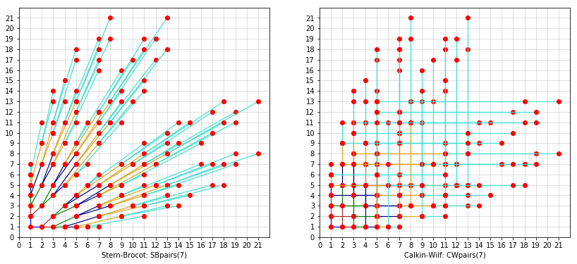

```python
#click to see  the code
xmax = 21
plt.rcParams["figure.figsize"] =  [14.0, 6.0]
fig = plt.figure()
sub1 = fig.add_subplot(1,2, 1)
tree = SBpairs(7)
for k in range(0,len(tree)-1):
    level_colors=['blue','brown','green','navy','goldenrod','turquoise']
    for i in range(len(tree[k])):
        pt = np.array(tree[k][i])
        pts = np.array([tree[k+1][2*i],tree[k+1][2*i+1]])
        plot_pt2pts(sub1,pt,pts,colors=[level_colors[k%len(level_colors)]])
        plot_points(sub1,pt.reshape(1,2))
        plot_points(sub1,pts)
gridticks(sub1,xmajticks=(0,xmax+1,1))
sub1.set_xlabel('Stern-Brocot: SBpairs(7)')

#plt.rcParams["figure.figsize"] =  [6.0, 14.0]
#fig = plt.figure()
sub4 = fig.add_subplot(1,2, 2)
tree = CWpairs(7)
for k in range(0,len(tree)-1):
    level_colors=['blue','brown','green','navy','goldenrod','turquoise']
    for i in range(len(tree[k])):
        pt = np.array(tree[k][i])
        pts = np.array([tree[k+1][2*i],tree[k+1][2*i+1]])
        plot_pt2pts(sub4,pt,pts,colors=[level_colors[k%len(level_colors)]])
        plot_points(sub4,pt.reshape(1,2))
        plot_points(sub4,pts)
gridticks(sub4,xmajticks=(0,xmax+1,1))
sub4.set_xlabel('Calkin-Wilf: CWpairs(7)')
plt.show()
```

Dans une grille de taille donnée, on peut placer tous les couples d'entiers copremiers présents dans cette grille We can put more nodes in the grid, plotting all the relatively prime integer's pairs present in the grid

```python
def rel_prime(a: int, b: int) -> bool:
    """ return True if a and b are relatively prime

    Args:
        a: int
        b: int
    Returns:
        True or False
    """
    if a == b == 1:
        return False
    return gcd(a,b) == 1
```

```python
rel_prime(3,8)
```

```
True
```

```
Text(0.5,0,'Stern-Brocot: coprimes pairs')
```

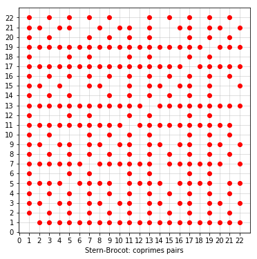

```python
#click to see the plot's code
xmax = 22
plt.rcParams["figure.figsize"] =  [6.0, 6.0]
fig = plt.figure()
sub = fig.add_subplot(1,1, 1)
for lin in range(1,xmax+1):
    xpts = [col for col in range(1,xmax+1) if rel_prime(col,lin)]
    ypts = len(xpts)*[lin]
    for i in range(len(xpts)):
        sub.plot(xpts[i], ypts[i], color='red', marker='o')
gridticks(sub,xmajticks=(0,xmax+1,1))
sub.set_xlabel('Stern-Brocot: coprimes pairs')
```

et visualiser un plus grand nombre de branches dans la grille, en dessinant tous les arcs liant les noeud visibles aux noeuds de leur père.  
On définit facilement une fonction `SBfather(frac)` retournant la fraction que porte le père d'un noeud `(n,d)`:

```python
def SBfather(frac: Union[Tuple[int, int], str]) -> Tuple[int, int]:
    # frac: Union[Tuple[int, int], Fraction[int, int], str]
    # -> Union[Tuple[int, int], Fraction[int, int]] type hint doesn't recognize Fraction
    """ find the father node of a Stern-Brocot node from the pair or fraction value or string fraction value

    Args:
        frac: a fraction as a tuple (numerator: int, denominator: int) as (3,8)
        or a string as '3/8' or a fraction as Fraction(3,8)
    Returns:
        the pair value of the father of frac if the frac parameter value was a pair
        the fraction value of the father of frac if the frac parameter value was a fraction or a string fraction
    """
    father = SBfrac(SBpath(frac)[:-1])
    if type(frac) is tuple:
        return father.numerator,father.denominator
    return father
```

```python
SBfather((3,8))
```

```
(2, 5)
```

```python
SBfather('3/8')
```

```
Fraction(2, 5)
```

Ou encore plus de branches en dessinant les liens reliant chaque noeud visible à ses fils gauche et droit. or again with more branches plotting the branches linking a node to his left and right sons.

```python
def SBsons(frac: Union[Tuple[int, int], str]) -> Tuple[Tuple[int, int],Tuple[int, int]]:
    # frac: Union[Tuple[int, int], Fraction[int, int], str]
    # -> Union[Tuple[int, int], Fraction[int, int]] type hint doesn't recognize Fraction
    """ find the (left son, right son) nodes pair of a Stern-Brocot tree node

    Args:
        frac: a fraction as a tuple (numerator: int, denominator: int) as (3,8)
        or a string as '3/8' or a fraction as Fraction(3,8)
    Returns:
        a pair of pair's values for the sons of frac if the frac parameter value was a pair
        a pair of fraction values for the sons of frac if the frac parameter value was a fraction or a string
    """
    path = SBpath(frac)
    sons = [SBfrac(path + 'L'),SBfrac(path + 'R' )]
    if type(frac) is tuple:
        return ((sons[0].numerator,sons[0].denominator),(sons[1].numerator,sons[1].denominator))
    return sons
```

```python
SBsons((2, 5))
```

```
((3, 8), (3, 7))
```

Dans le cas où les noeuds ne sont pas dans le rectangle défini par la grille il faut couper les arcs correspondants (clipping).

```python
def xylinefrom(*pts: np.array) -> Tuple[Tuple[float,float],Tuple[float,float]]:
    """ compute 2 pairs (x0,x1),(y0,y1) to be plotted by matlib.plot

    Args:
        pts : a np.array of 2 or 3 points in the plane
        the 2 pts pts[0] and pts[1] verifying:
           0 < pts[0][0] < pts[1][0]
           0 < pts[0][1] < pts[1][1]
        if present, the third point defines a clipping
        window (0,xmax=pts[2][0]),(0,ymax=pts[2][1])
        to the segment defined by pts[0]to pts[1].
    Returns:
        two pairs (x0,x1),(y0,y1) defining the segment
        ready to be plotted by matlib.plot
    """
    xs = [pt[0] for pt in pts]
    ys = [pt[1] for pt in pts]
    if len(pts) == 2:
        return xs,ys
    else:
        m = (ys[1]-ys[0])/(xs[1]-xs[0])
        if xs[1] > xs[2]:
            xs[1] = xs[2]
            ys[1] = ys[0] + m*(xs[1]-xs[0])
        if ys[1] > ys[2]:
            ys[1] = ys[2]
            xs[1] = xs[0] + (xs[1]-xs[0])/m
    return xs[:2],ys[:2]
```

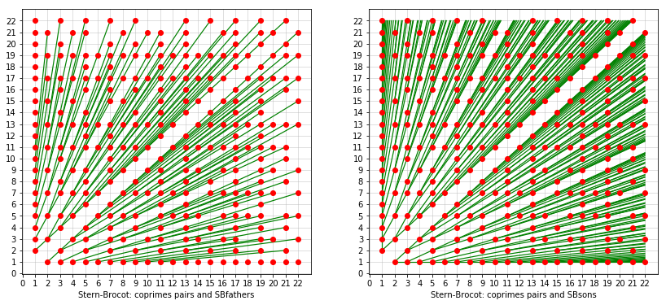

```python
#click to see the plot's code
xmax = 22
plt.rcParams["figure.figsize"] =  [14.0, 6.0]
fig = plt.figure()

sub2 = fig.add_subplot(1,2, 1)
for lin in range(2,xmax+1):
    xpts = [col for col in range(lin+1,xmax+1) if rel_prime(col,lin)]
    ypts = len(xpts)*[lin]
    for i in range(len(xpts)):
        xpair,ypair = np.array((SBfather((xpts[i],lin)),(xpts[i],lin))).T
        sub2.plot(xpair, ypair, color='green', linewidth=1.2)
        sub2.plot(ypair, xpair, color='green', linewidth=1.2)
for lin in range(1,xmax+1):
    xpts = [col for col in range(1,xmax+1) if rel_prime(col,lin)]
    ypts = len(xpts)*[lin]
    for i in range(len(xpts)):
        sub2.plot(xpts[i], ypts[i], color='red', marker='o')
gridticks(sub2,xmajticks=(0,xmax+1,1))
sub2.set_xlabel('Stern-Brocot: coprimes pairs and SBfathers')


#xmax = 22
#plt.rcParams["figure.figsize"] =  [6.0, 6.0]

sub3 = fig.add_subplot(1,2, 2)
for lin in range(1,xmax+1):
    xpts = [col for col in range(lin+1,xmax+1) if rel_prime(col,lin)]
    ypts = len(xpts)*[lin]
    for i in range(len(xpts)):
        left,right = SBsons((xpts[i],lin))
        #xpair,ypair = pts2xys(SBfather((xpts[i],lin)),(xpts[i],lin))
        xpair,ypair = xylinefrom((xpts[i],lin),left,(xmax,xmax))
        sub3.plot(xpair, ypair, color='green', linewidth=1.2)
        sub3.plot(ypair, xpair, color='green', linewidth=1.2)
        xpair,ypair = xylinefrom((xpts[i],lin),right,(xmax,xmax))
        sub3.plot(xpair, ypair, color='green', linewidth=1.2)
        sub3.plot(ypair, xpair, color='green', linewidth=1.2)
for lin in range(1,xmax+1):
    xpts = [col for col in range(1,xmax+1) if rel_prime(col,lin)]
    ypts = len(xpts)*[lin]
    for i in range(len(xpts)):
        sub3.plot(xpts[i], ypts[i], color='red', marker='o')
gridticks(sub3,xmajticks=(0,xmax+1,1))
sub3.set_xlabel('Stern-Brocot: coprimes pairs and SBsons')
plt.show()
```